# Expected Value and Variance of Random Variables

Stat 241

## Warm-Up

**Example 1.** Suppose a student has taken $10$ courses and received $5$ A’s, $4$ B’s, and $1$ C. Using the traditional numerical scale where an A is worth $4$, a B is worth $3$, and a C is worth $2$, what is this student’s GPA (grade point average)?

Consider now a correct way to do this calculation:
$$\begin{align*}
\mbox{GPA} &= \frac{4 + 4 + 4 + 4 + 4 + 3 + 3 + 3 + 3 + 2}{10}
\\[2mm]
& = \frac{5\cdot 4 + 4\cdot 3 + 1 \cdot 2}{10} \\[1mm]
& = \frac{5}{10} \cdot 4 + \frac{4}{10}\cdot 3 + \frac{1}{10} \cdot 2 \\
& = 4 \cdot \frac{5}{10} + 3 \cdot \frac{4}{10} + 2 \cdot \frac{1}{10} \\
& = 3.4 \;.
\end{align*}$$

## Expected Value

### The big idea

The key idea here is that the mean is a **sum** of **values** times **probabilities**.

We can write this as
$$\mbox{mean} = \sum \mbox{value} \cdot \mbox{probability}$$

### Discrete Random Variables

For a discrete random variable this translates to
$$\mu_X = \operatorname{E}(X) = \sum x f(x)$$
where the sum is taken over all possible values of $X$ and $f$ is the pmf for $X$.

**Example 2.** Let $X$ be discrete random variable with probablilities given in the table below.

| value of $X$ | 0 | 1 | 2 |
| --- | --- | --- | --- |
| **probability** | 0.2 | 0.5 | 0.3 |

What is the mean (expected value) of $X$?

$E(X) = 0 \cdot 0.2 + 1 \cdot 0.5 + 2 \cdot 0.3 = 0.5 + 0.6 = 1.1$ This value reflects the fact that the random variable is larger than 1 a bit more often than it is less than 1.

**Example 3.** A local charity is holding a raffle. They are selling $1000$ raffle tickets for $5 each. The owners of five of the raffle tickets will win a prize. The five prizes are valued at $25, $50, $100, $1000, and $2000.  
Let $X$ be the value of the prize associated with a random raffle ticket ($0 for non-winning tickets).

1. What is the probability of winning a prize?
2. What is the probability of winning the grand prize?
3. What is the expected value of the prize?
- $\operatorname{P}{\mbox{the ticket wins a prize}} = \operatorname{P}(X > 0) = 5/1000$.
- $\operatorname{P}{\mbox{the ticket wins the grand prize}} = \operatorname{P}(X = 2000) = 1/1000$.
- $\operatorname{P}{\mbox{the ticket wins a prize worth more than} 75 dollars} = \operatorname{P}(X > 75) = 3/1000$.

The expected value of a ticket is

$$0 \cdot \frac{995}{1000}
+ 25 \cdot \frac{1}{1000}
+ 50 \cdot \frac{1}{1000}
+ 100 \cdot \frac{1}{1000}
+ 1000 \cdot \frac{1}{1000}
+ 2000 \cdot \frac{1}{1000}$$

```r
25 * .001 + 50 * 0.001 + 100 * 0.001 + 1000 * 0.001 + 2000 * 0.001
```

```
## [1] 3.175
```

```r
# R can help us set up this sum:
sum(c(25, 50, 100, 1000, 2000) * 0.001)
```

```
## [1] 3.175
```

### Continuous Random Variables

When working with a continuous random variable, we replace the sum with an integral and replace the probabilities with our density function to get the following definition:

$$\operatorname{E}(X) = \mu_X = \int_{-\infty}^{\infty} x f(x) \; dx$$

**Example 4.** Calculate the mean of a symmetric triangle distribution on $[-1, 1]$.

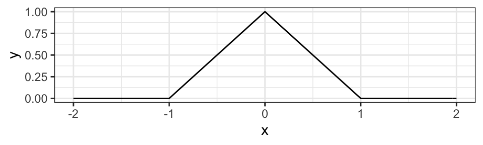

We could also calculate this numerically in R:

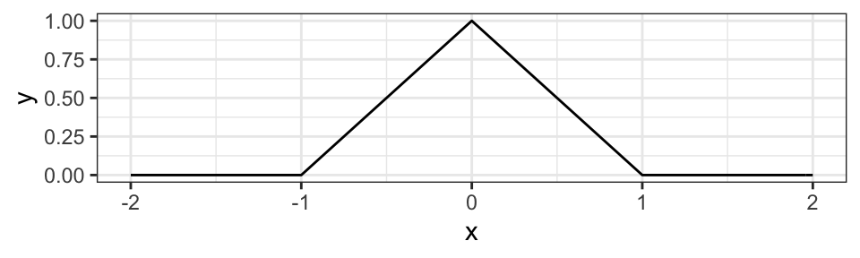

```r
library(mosaicCalc)
# define the function -- (abs(x) <= 1) will converted to 0 or 1
f <- makeFun( (1 - abs(x)) * (abs(x) <= 1) ~ x)

# plot the function to make sure it looks right
gf_function(f, xlim = c(-2, 2))
```

```r
# define x * f(x) as another function
xf <- makeFun( x * f(x) ~ x )
# integrate over the interval from -1 to 1 to get E(X)
integrate(xf, -1, 1)
```

```
## 0 with absolute error < 3.7e-15
```

```r
# use anti-derivative instead -- lower.bound sets the "zero point" for the anti-derivative
F <- antiD( x * f(x) ~ x, lower.bound = -1)
F(-1)  # should be 0 because of lower.bound
```

```
## [1] 0
```

```r
F(1)   # should be the expected value -- also 0.
```

```
## [1] 0
```

## Variance

Arguing similarly, we can compute the variance of a discrete or continuous random variable using

- discrete: $\operatorname{Var}(X) = \sigma^2_X = \sum_x (x-\mu_X)^2 f(x) \; dx$
- continuous: $\operatorname{Var}(X) = \sigma^2_X = \int_{-\infty}^{\infty} (x-\mu_X)^2 f(x) \; dx$

These can be combined into a single definition by writing
$$\operatorname{Var}(X) = \operatorname{E}((X - \mu_X)^2) \;.$$
Note: It is possible that the sum or integral used to define the mean (or the variance) will fail to converge. In that case, we say that the random variable has no mean (or variance) or that the mean (or variance) fails to exist.[^1]

**Example 5.** Compute the variance of symmetric triangle distribution on $[-1,1]$.

```r
f <- makeFun( (1 - abs(x)) * (abs(x) <= 1) ~ x)
xxf <- makeFun( (x-0)^2 * f(x) ~ x )
integrate(xxf, -1, 1)
```

```
## 0.1666667 with absolute error < 1.9e-15
```

```r
G <- antiD( (x-0)^2 * f(x) ~ x)
G(1) - G(-1)
```

```
## [1] 0.1666667
```

### Useful identity

Some simple algebraic manipulations of the sum or integral above shows that

$$\begin{align}
\operatorname{Var}(X) &= \operatorname{E}(X^2) - \operatorname{E}(X)^2
\end{align}$$

**Example 6.** Compute the mean and variance of the random variable with pdf given by

$$g(x) = \frac{3x^2}{8} [\![ \; x \in [0,2] \; ]\!] \;.$$

```r
g <- makeFun( (3 * x^2/8 ) * (0 <= x & x <= 2) ~ x )
m <- antiD( x * g(x) ~ x, lower.bound = 0)(2)  # all in one step instead of defining F or G
m
```

```
## [1] 1.5
```

```r
v <- antiD( (x - m)^2 * g(x) ~ x, m = m, lower.bound = 0)(2)
v
```

```
## [1] 0.15
```

```r
# here's the alternate computation
antiD( x^2 * g(x) ~ x, lower.bound = 0)(2) - m^2
```

```
## [1] 0.15
```

As with data, the standard deviation is the square root of the variance.

## More Practice

**1.** You are invited to play the following game. You draw two chips without replacement from a jar containing 5 red, 5 blue, and 5 green chips. If both chips have the same color you win $5. If the two chips have different colors, you win $3. On average, how much will you win per game? It costs you $4 to play the game. On average, would you win money, lose money, or break even playing this game?

**2.** Toss a fair coin 3 times. Let X be the number of heads produced. Find the pmf for $X$ and use it to find the average number of heads produced when the coin is tossed 3 times.

**3.** Repeat the previos problem above under the assumption that the coin is biased and only has a 1/4 chance of producing a head.

**4.** Let $f(x) = 2e^{-2x}$ on $(0, \infty)$. Create this function in R and use R to integrate it on $[0, \infty)$. Note that $e^x$ is expressed in R as `exp(x)`.

1. Is $f(x)$ is a pdf?
2. Use R to compute $\operatorname{P}(-1 \le X \le 3)$.
3. Use R to compute the cumulative distribution function $F$ and use $F$ to compute $\operatorname{P}(3 \le X \le 10)$.
4. Use R to compute the mean of $X$.

**5.** Let $X$ have the pdf $f(x) = 2x$ on $[0, 1]$.

1. Find the median of $X$. [Hint: What is a median? – Don’t think about sorting.]
2. What is the 20th percentile of $X$?

**6.** Do the following by hand, without using R. Let $f(x) = C x^3$ on $[0, 3]$ be the pdf for $X$.

1. What is the value of $C$?
2. Compute $\operatorname{E}(X)$.
3. Compute $\operatorname{P}(X > 2)$.
4. Determine the median of $X$.
[^1]: Actually, we will require that $\int_{\infty}^{\infty} |x| f(x) \; dx$ converges and $\int_{\infty}^{\infty} |x|^2 f(x) \; dx$ converges. If these integrals (or the corresponding sums for discrete random variables) fail to converge, we will say that the distribution has no mean (or variance).